# Campus Placement Analysis for Jain University

## 0.1 Introduction

### 0.1.1 Overview

The [dataset](https://www.kaggle.com/benroshan/factors-affecting-campus-placement) consists of campus placement data for MBA Business Analytics students from Jain University in Bangalore, India. There are 215 observations and 15 variables Dataset has information on:

- placement status of the student
- salary offered to students who were placed
- MBA specialization and grade
- Record of previous employment
- specialization and grade for undergraduate, higher secondary, and secondary education

### 0.1.2 List of Variables

- `sl_no`: Serial Number of the observations for each student
- `gender`: Male = ‘M’; Female = ‘F’
- `ssc_p`: Secondary Education percentage (10th grade)
- `ssc_b`: Board of Education for Secondary (Central / Others)
- `hsc_p`: Higher Secondary Education percentage (12th grade)
- `hsc_b`: Board of Education for Higher Secondary (Central / Others)
- `hsc_s`: Specialization in Higher Secondary Education (Commerce / Science / Other)
- `degree_p`: Degree Percentage
- `degree_t`: Under Graduation degree type (Field of education)
- `workex`: Record of previous work experience (Yes / No)
- `etest_p`: Employability test percentage (conducted by college)
- `specialisation`: Post Graduation (MBA) specialization (Mkt&Fn / Mkt &HR)
- `mba_p`: MBA percentage
- `status`: Status of placement (Placed / Not Placed)
- `salary`: Annual salary offered by corporate to candidates who were placed

## 0.2 Exploratory Data Analysis

The exploratory data analysis is divided into two sections. First, the relationship between `status` and all the relevant dependent variables, excluding `sl_no` and `salary`, are examined. In the second section, the influence on `salary` is inspected.

### 0.2.1 Influence on Status

#### 0.2.1.1 What is the placement rate?

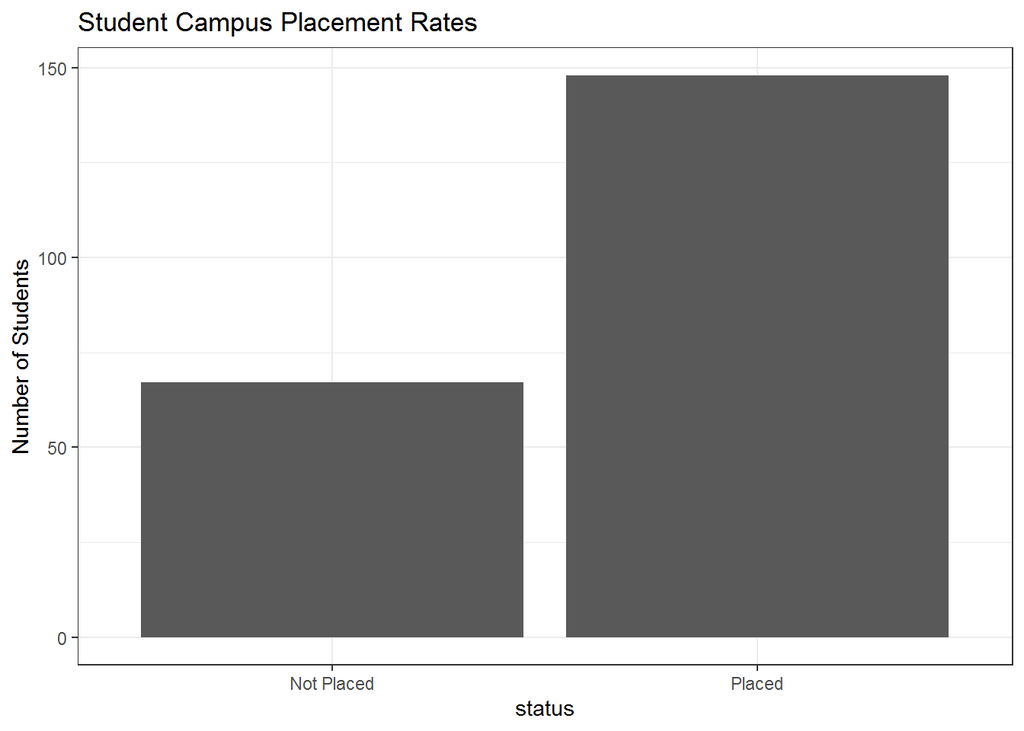

Student Campus Placement Rates

```r
prop.table(table(placement$status)) * 100
```

```
##
## Not Placed     Placed
##   31.16279   68.83721
```

**Remark:** Approximately 69% students were hired and 31% were not.

#### 0.2.1.2 What is the status by work experience?

Hypothesis is that candidates with previous work experience are likely to get hired.

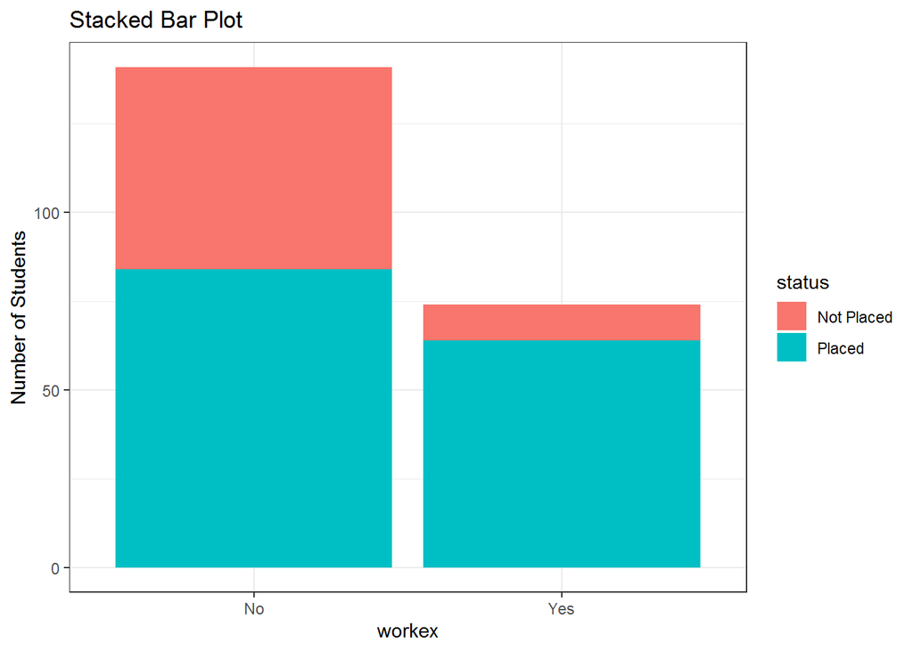

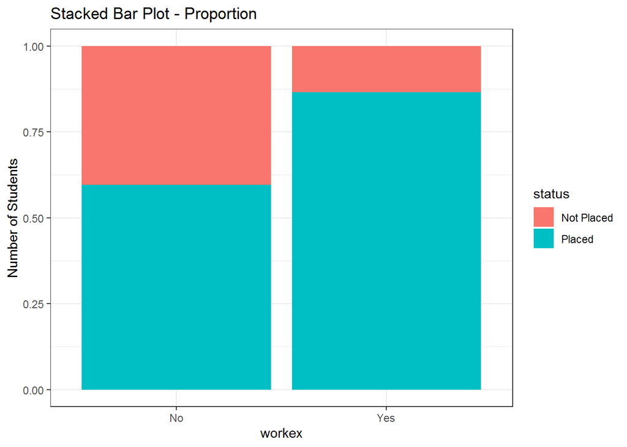

**Remark:** The bar plot on the left shows that more students did not have work experience. The proportion bar plot on the right shows that almost 60% of students without work experience were placed, whereas the placement rate for students with work experience is almost 90%. This result matches with the hypothesis.

#### 0.2.1.3 What is the status by employment test score?

The employment test was conducted by the college. Hypothesis is that this test score positively influences the placement decision.

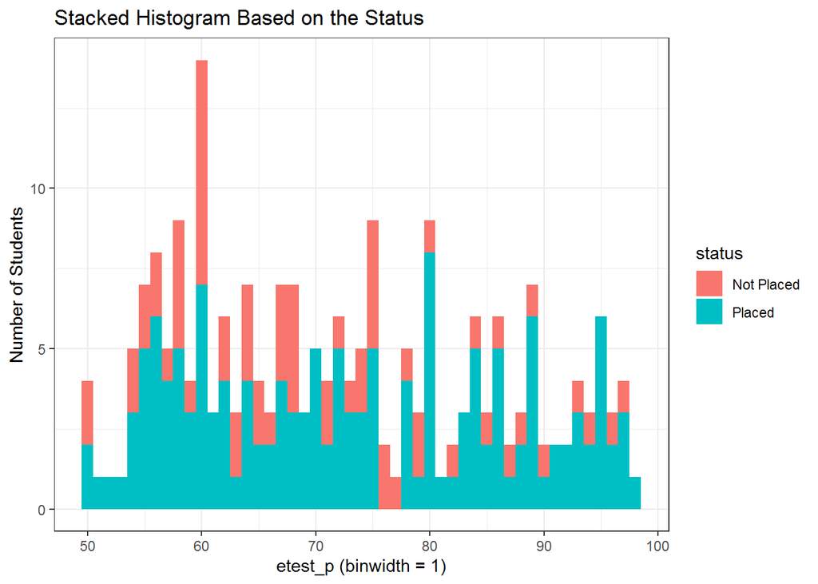

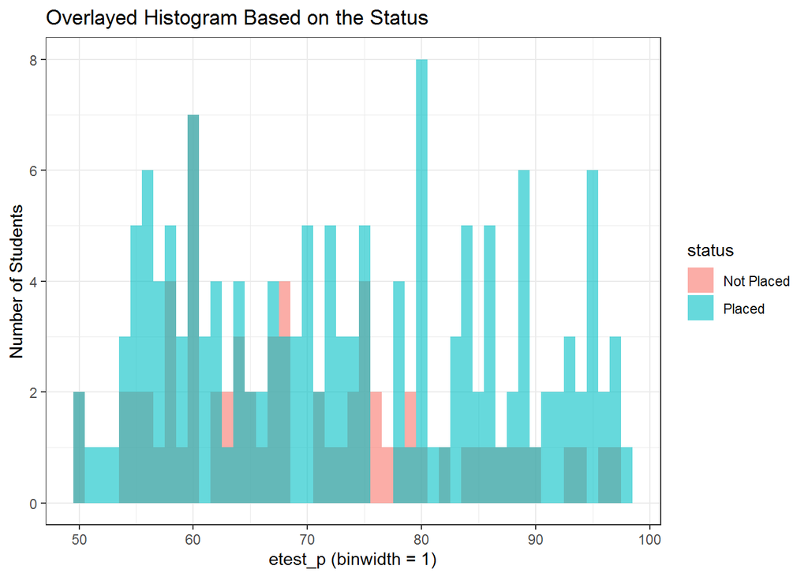

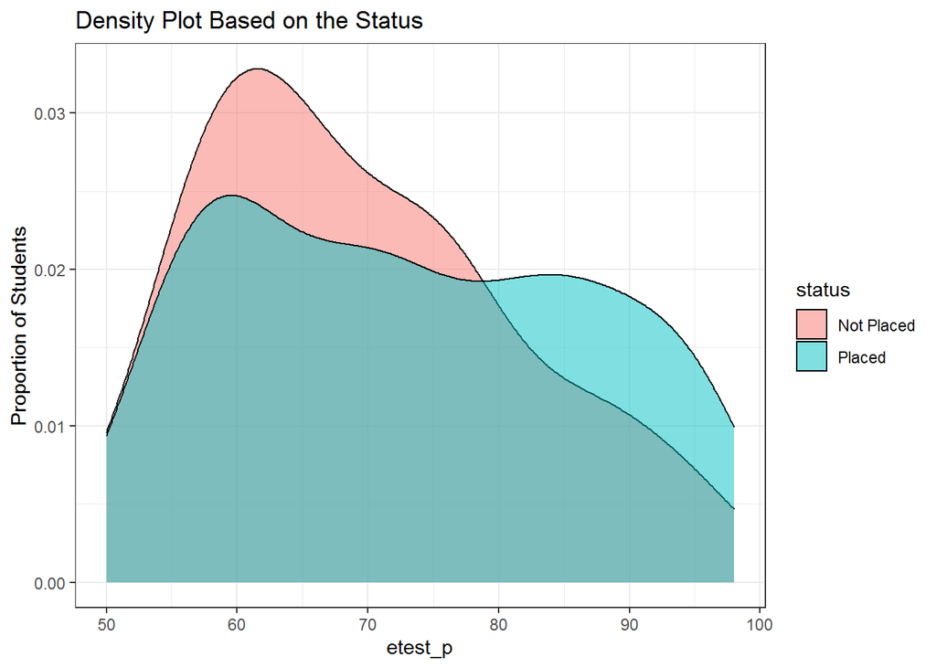

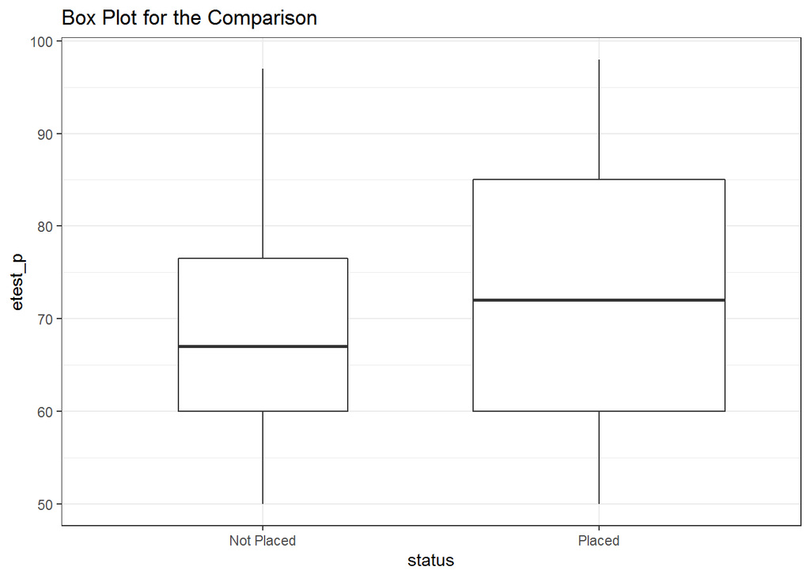

**Remark:** The histogram and density plots for employment test scores with respect to status shows that, in general, for higher test scores, a greater percentage of students were placed than not placed.

The boxplot shows the test score for students who were not placed in the interquartile range 60-76 (median = 67), and for those placed in the interquartile range 60-85 (median = 72). Therefore, it is certain that students with high employment test scores were preferred for placement, but those with scores 60-76 who were also placed, there must be other factors that influenced it.

#### 0.2.1.4 How does the status depend on both employement test and work experience?

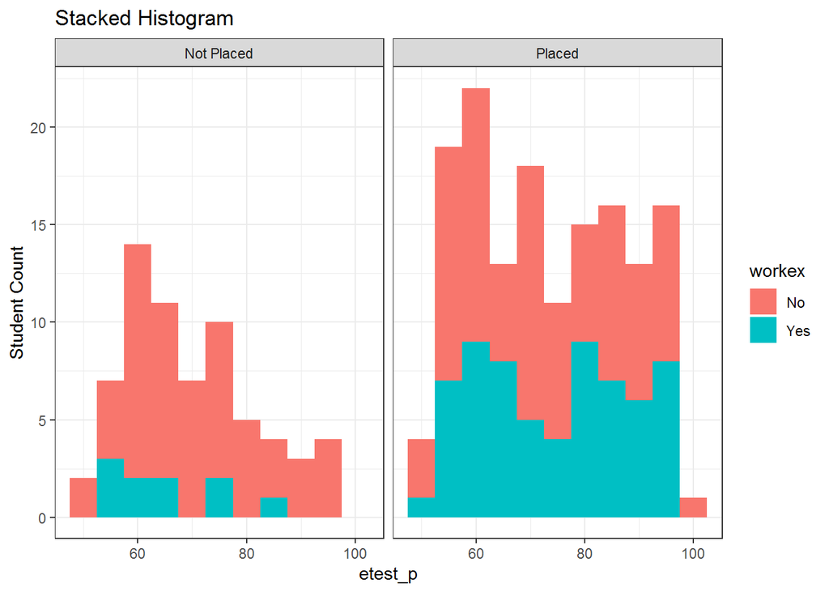

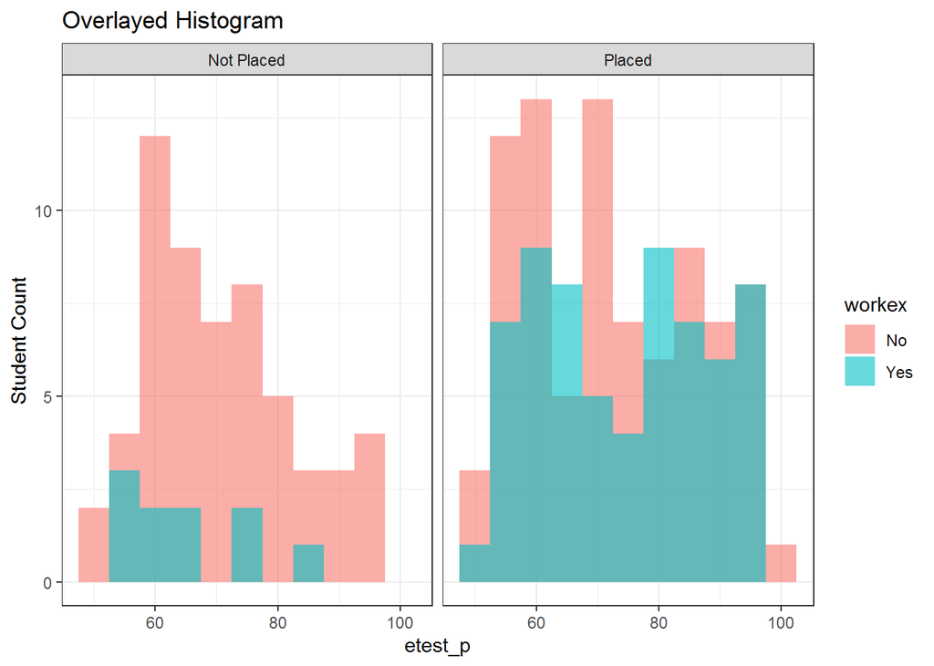

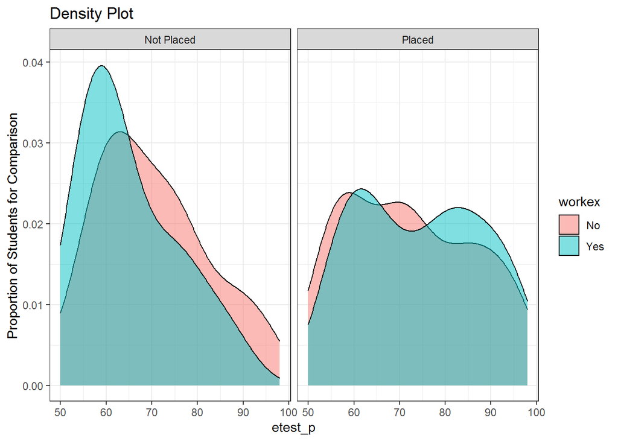

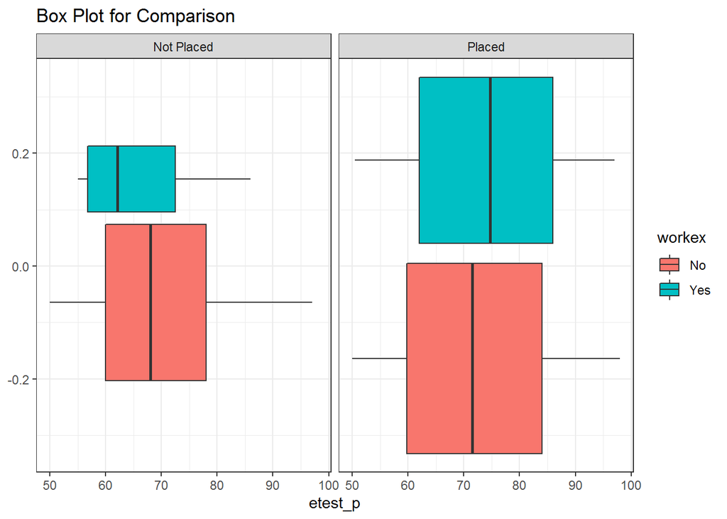

**Remark:** From the histogram plots it is clear that a very small percentage of students with previous work experience were not placed, and more among these students had low employment test score than high. However, for the students who were placed, `etest_p` scores does not seem to have any effect on the placement decision.

Notice the comparision between the density and box plots, specifically how clear the distinction is for the box plot.

In the box plot, we see that among the students who were not placed, the median etest score for those with work exprience were lower than those without. Among the students who were placed, we see the opposite, but the interquartile range almost overlaps. Comparing the status and employment test scores for students without work experience, we see that the interquartile range overlaps.

#### 0.2.1.5 What is the effect of MBA test score on placement status?

Hypothesis is that there is positive correlation.

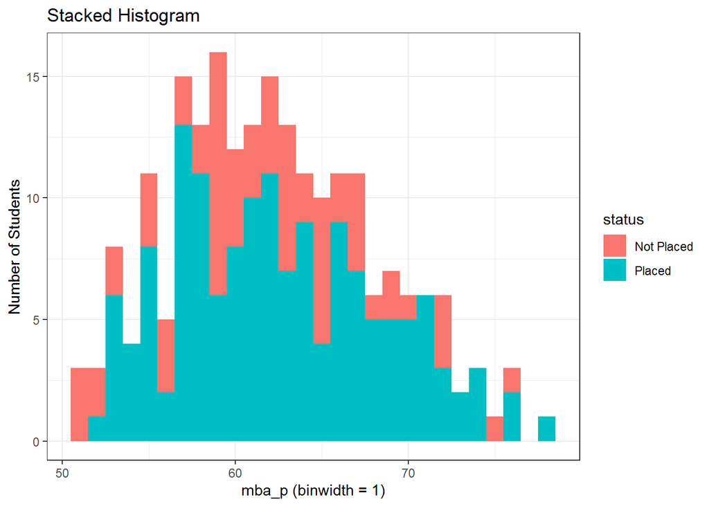

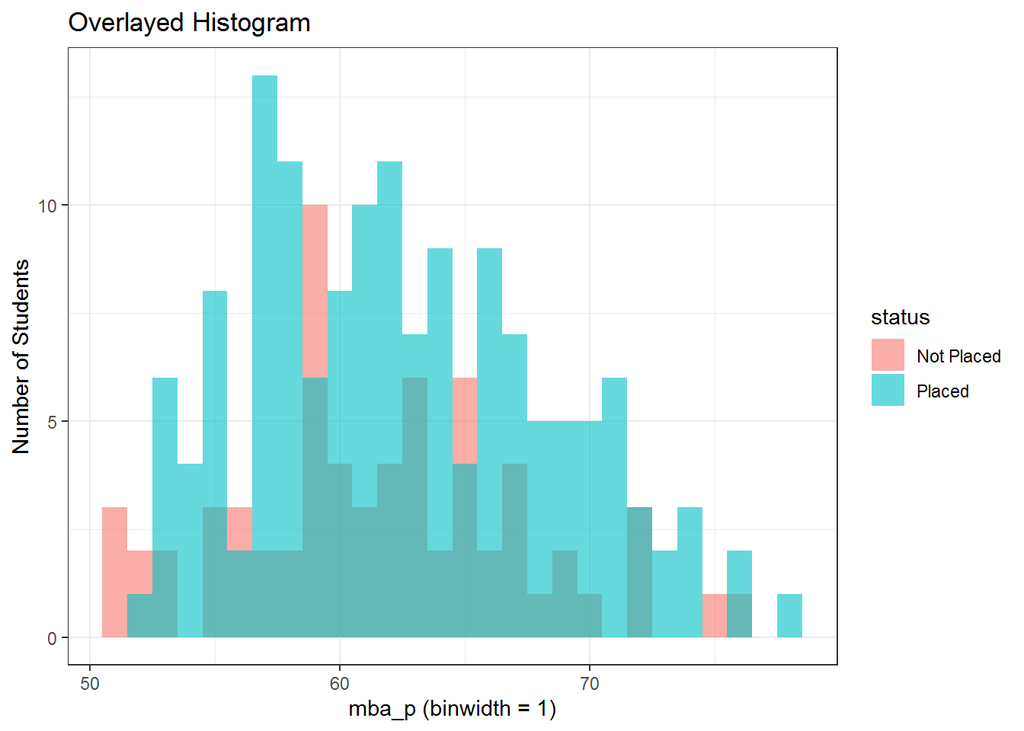

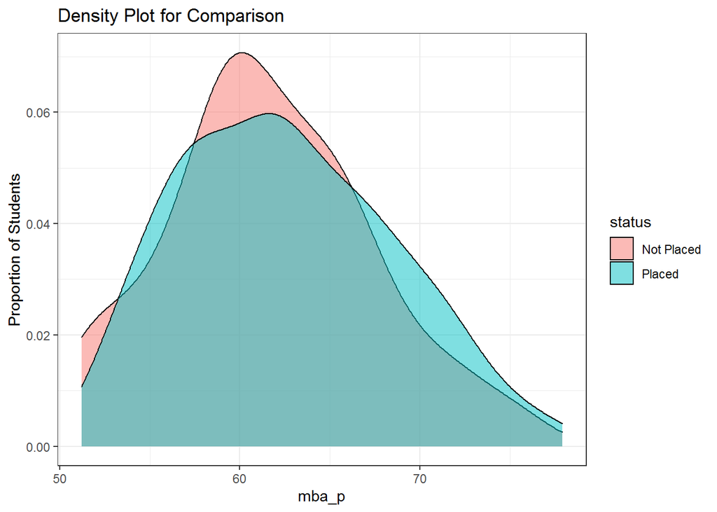

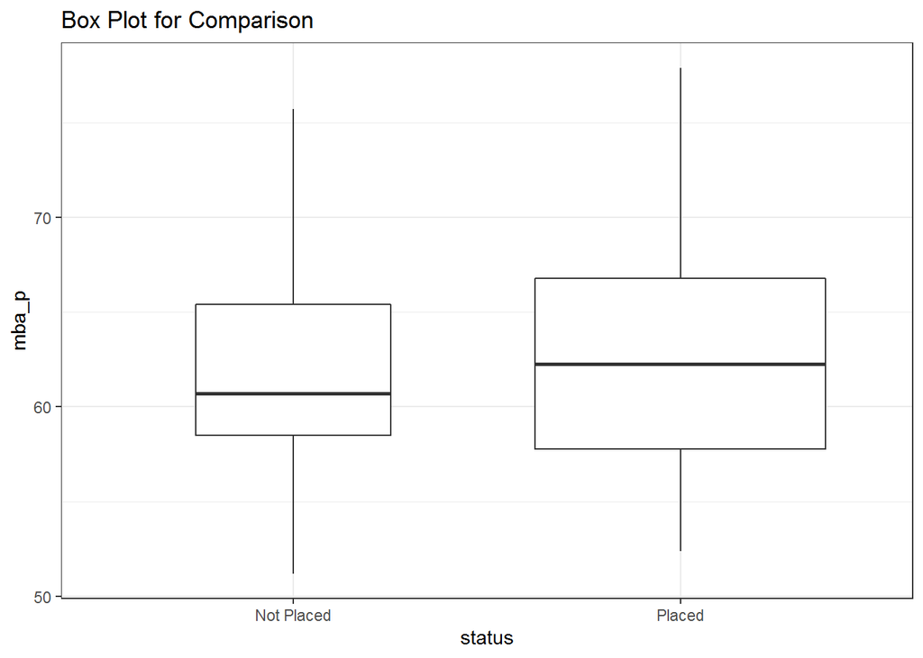

**Remark:** The plot shows the hypothesis to hold for the lowest and the highest mba_p scores, but for the scores in between the visual evidence is not strong. So we cannot correctly conclude that the hypothesis holds.

Specifically, the density plot and box plot show the interquaritlie range for Placed category (57-66) is wider and overlaps that of the Not Placed category (58-65). Distributions for both categories are skewed to the right. Median score for Placed is around 62 and median score for Not Placed is 61.

#### 0.2.1.6 Did the MBA specialization play a role in the hiring process?

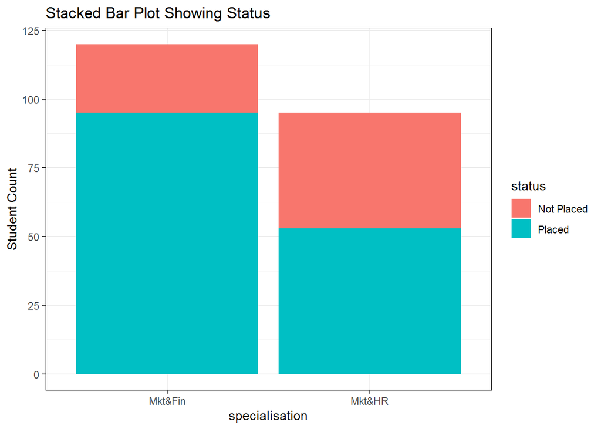

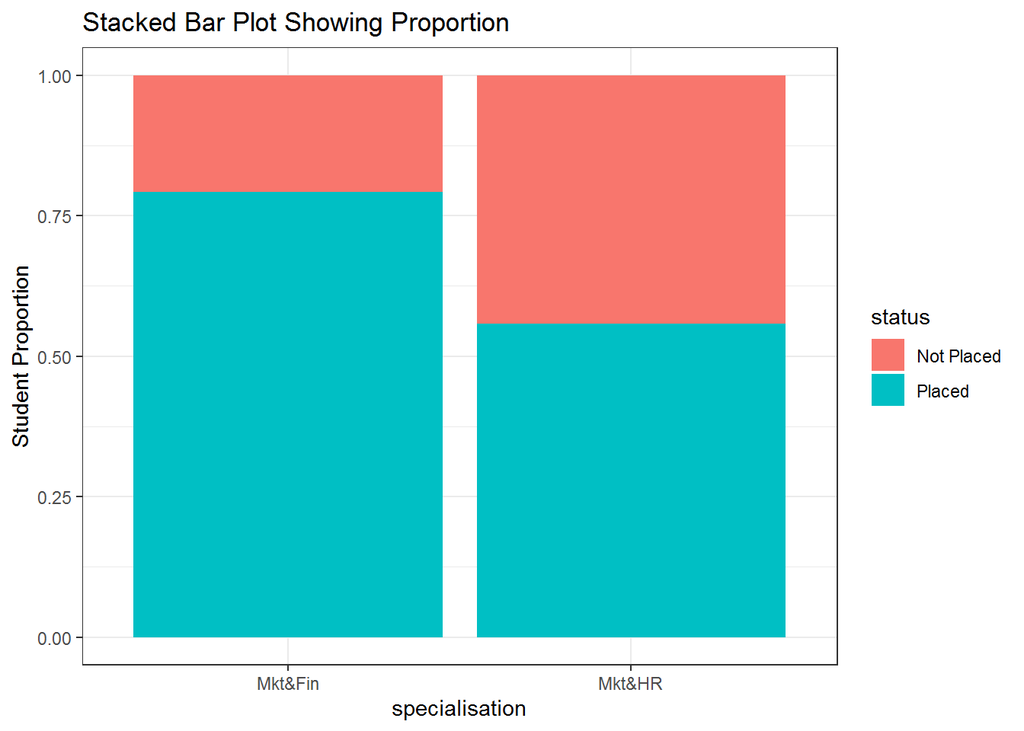

**Remark:** We see that more students specialized in Mkt&Fin than Mkt&HR. In addition, we see that a more candidates with Mkt&Fin specialization were hired. Based on the proportion bar plot, the ratio of receiving placement for the two MBA streams is ~80% : ~55%.

#### 0.2.1.7 What is the effect of undergraduate degree stream?

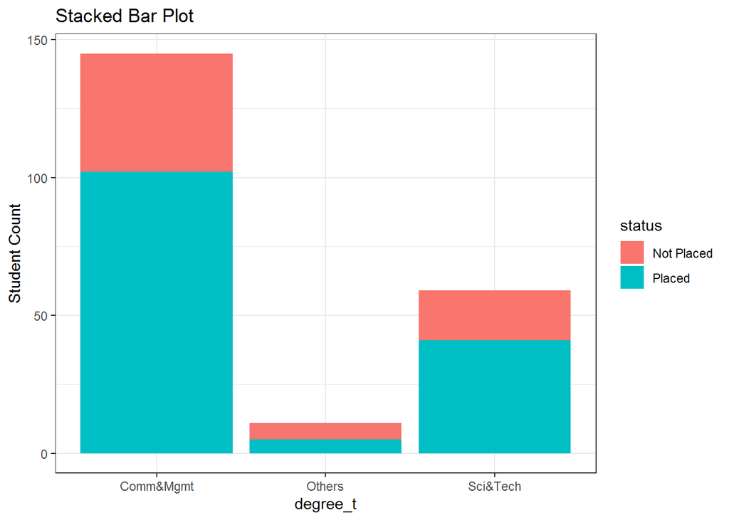

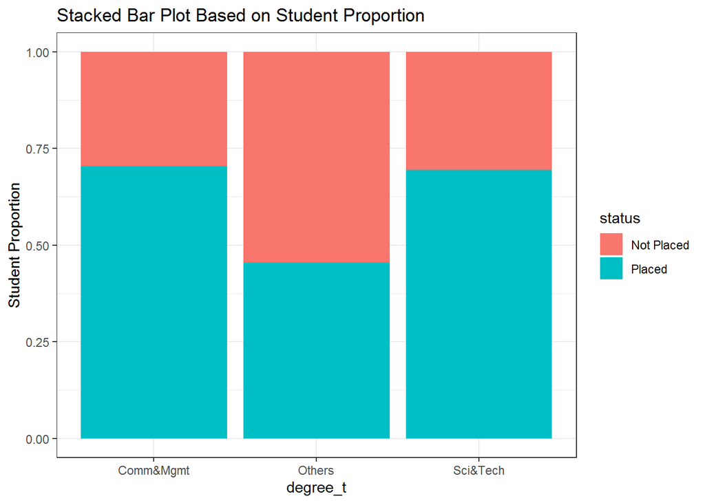

**Remark:** The first bar plot shows that the number of students in Comm&Mgmt are a lot more than Sci&Tech and other streams combined. But from the proportion bar plot We see that equal proportion of students from Comm&Mgmt and Sci&Tech were hired. And less than 50% of students from other streams were hired.

#### 0.2.1.8 How does both undergraduate degree stream and degree test score reflect on status?

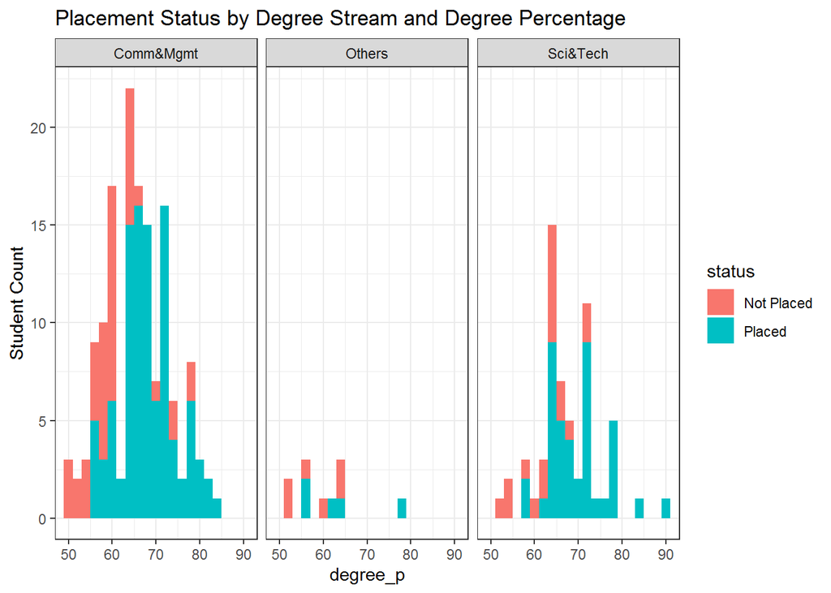

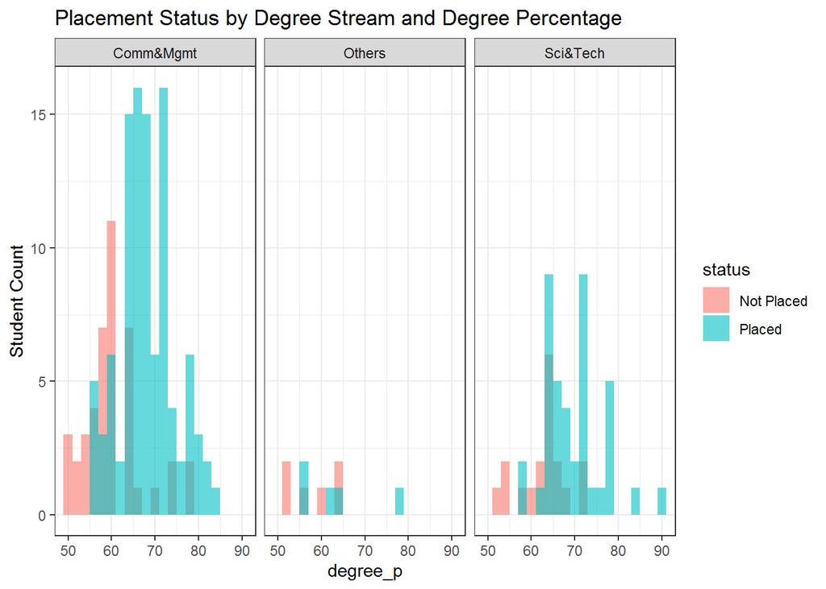

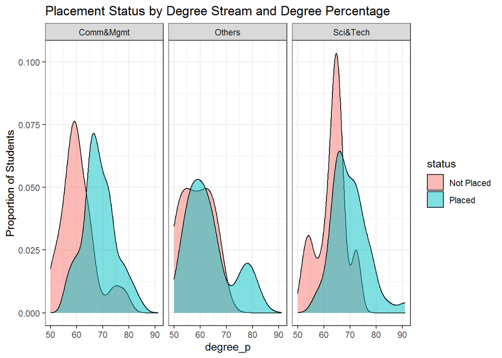

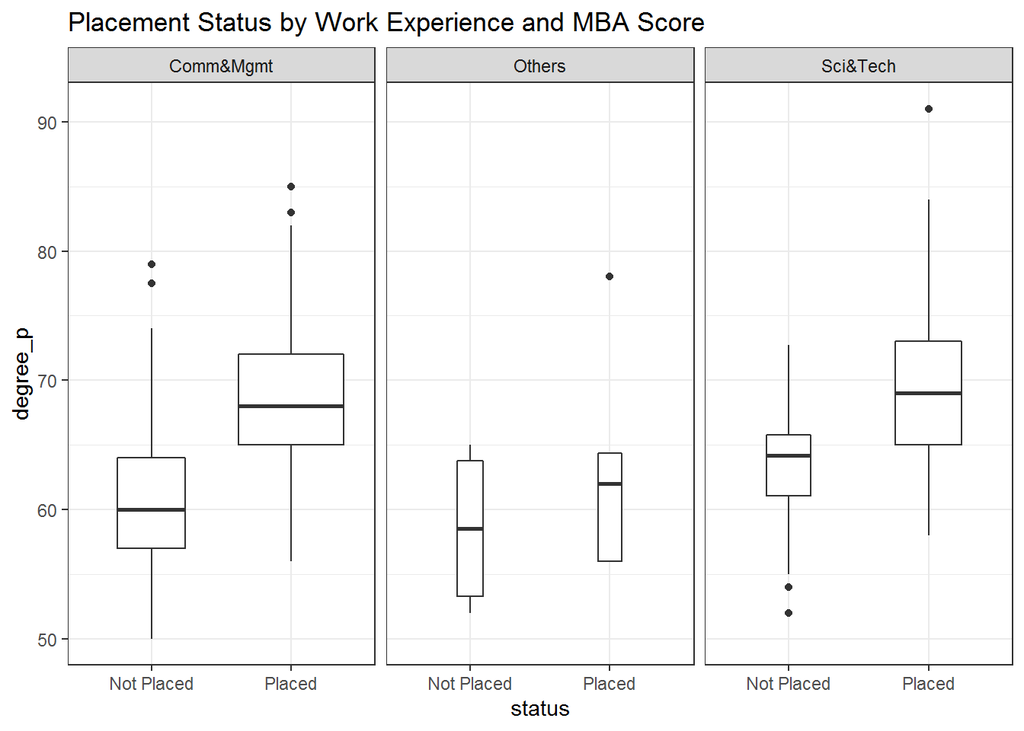

**Remark:** According to the histograms and the density plot, across all streams, candidates with higher degree percentage were preferred. From the box plot it is noticed that for the other streams, the preferene for higher degree test is not as evident. *Note that when it comes to test scores the outliers in the box plot are not relevant.*

#### 0.2.1.9 How does both higher secondary degree stream and test score influence the placement decision?

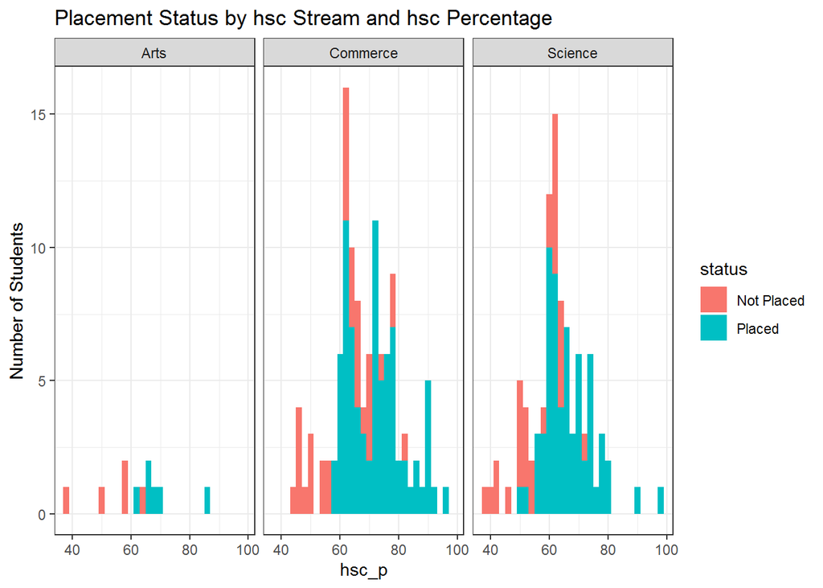

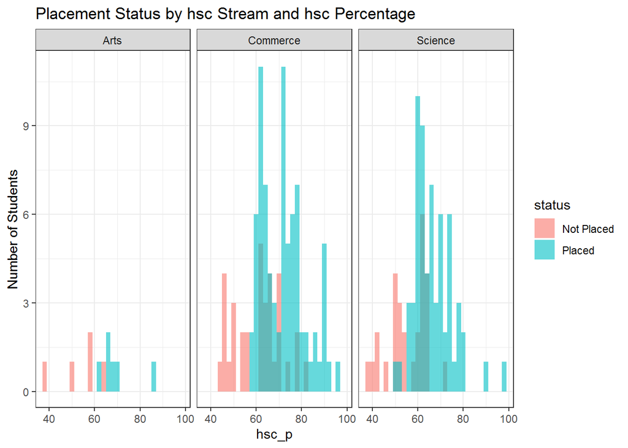

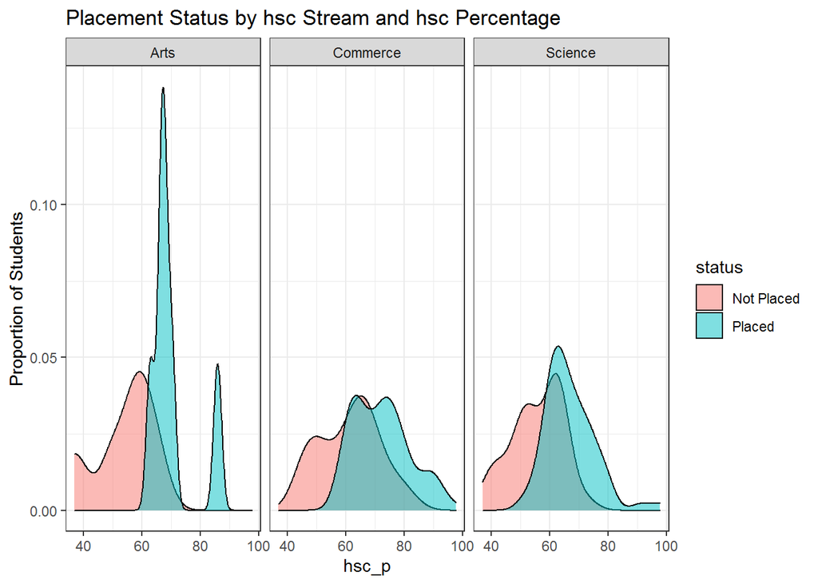

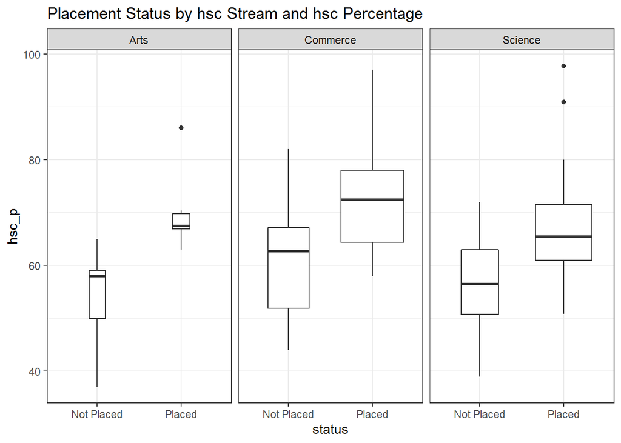

**Remark:** Dividing the placement status according to the science, commerce, and arts streams, we see that students who were placed generally had higher hsc scores than those who were not placed.

#### 0.2.1.10 Did the secondary test score have an effect?

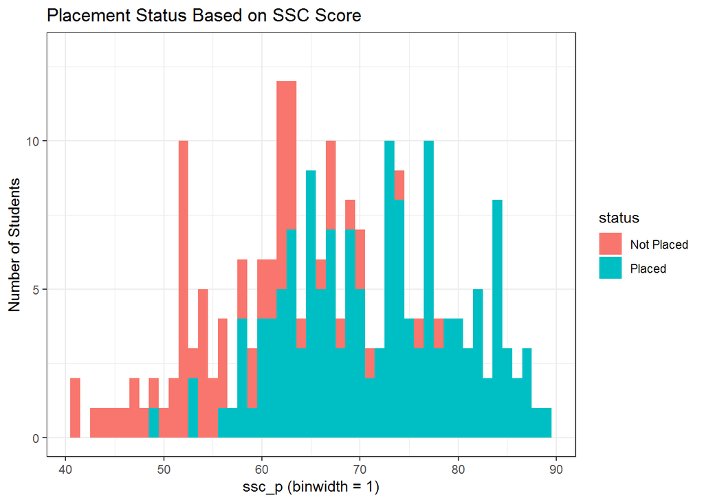

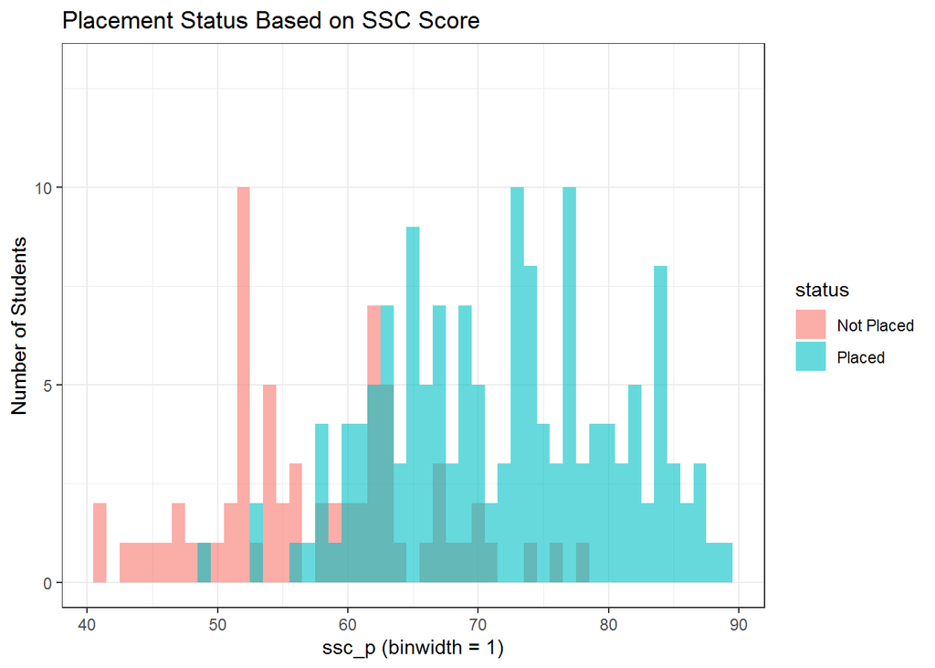

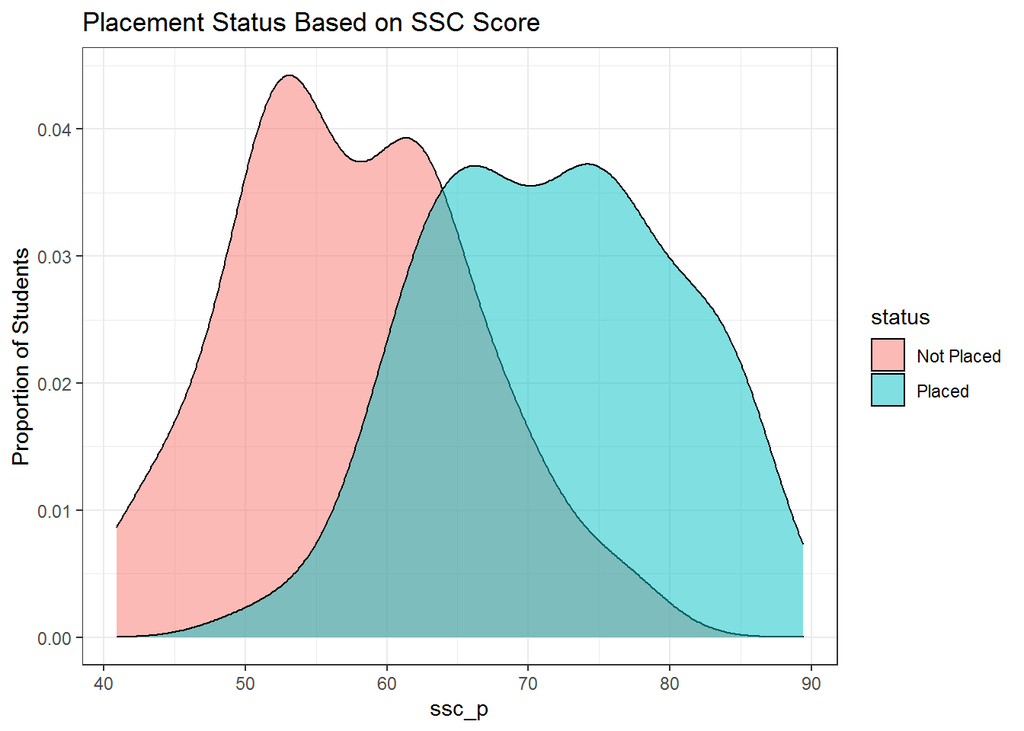

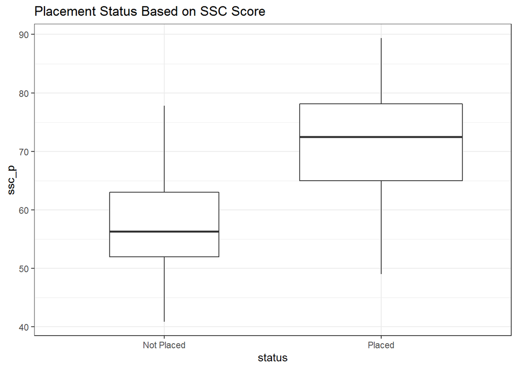

**Remark:** For secondary school education the streams were not provided, or they do not exist. Based on the density plot and box plot we see that candidates with higher ssc percentages were preferred for placement. Students who were hired have a significantly high ssc test score and the interquartile range of for the two groups do not overlap.